# Gene/pathway level analysis of microbiome in cancer immunotherapy patients

## Load packages

```r
library(tidyverse)
library(readr)
library(reshape2)
```

```r
library(umap)
library(pheatmap)
library(randomForest)
library(pROC)
```

## Load data

- **geneAbundance**
  - Abundances in copies per million mapped reads (CoPM) for each UNIREF90 gene cluster
- **pathAbundance**
  - Abundances in copies per million mapped reads (CoPM) for Metacyc pathways
- **pathCoverage**
  - Value between zero to one, representing the total coverage of each pathway.  
    Can be seen as a probability for a given pathway to exist in each sample.
- **clin**
  - Clinical metadata for each sample.

```r
geneAbundance = readRDS(file = "/Users/angelol/Documents/PhD/Gut-microbiome-immunotherapy/data/humann2/geneAbundance_merged_filtered.rds")
pathAbundance = readRDS(file = "/Users/angelol/Documents/PhD/Gut-microbiome-immunotherapy/data/humann2/pathAbundance_merged_filtered.rds")
pathCoverage = readRDS(file = "/Users/angelol/Documents/PhD/Gut-microbiome-immunotherapy/data/humann2/pathCoverage_merged_filtered.rds")
clin = readRDS(file = "/Users/angelol/Documents/PhD/Gut-microbiome-immunotherapy/Metadata/Processed_metadata/clin.rds")

# Sort according to alphabetical order, MOVE TO PRE-PROCESSING SCRIPTS
geneAbundance = geneAbundance[,order(colnames(geneAbundance))]
pathAbundance = pathAbundance[,order(colnames(pathAbundance))]
pathCoverage = pathCoverage[,order(colnames(pathCoverage))]
```

## Visualisation

Let’s start by visualising the structure of our data using PCA/tSNE.

For this, we need to log-normalise our data. We add one pseudo-CoPM to each gene/pathway in the gene/pathway abundance matrices in order to avoid taking the log of zero.

```r
geneAbundance = log2(geneAbundance + 1)
pathAbundance = log2(pathAbundance + 1)
```

The data should now be fairly normally distributed for PCA, so let’s take a look at the median abundance distributions for all samples. For the pathCoverage matrix we look at the mean coverage distribution, as the matrix is heavily inflated with ones and zeros

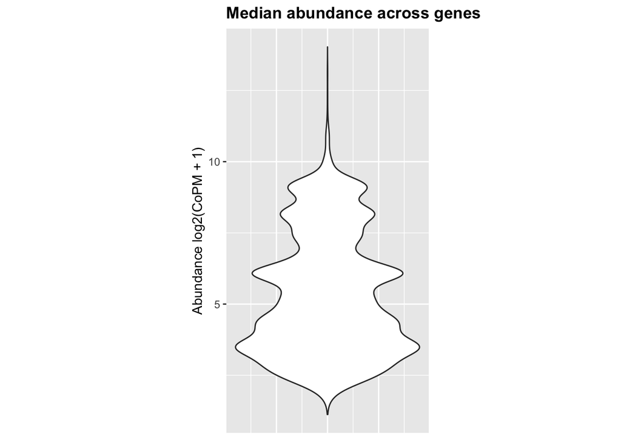

```r
median_geneabundance = apply(geneAbundance, 1, median)
median_pathabundance = apply(pathAbundance, 1, median)
mean_pathCoverage = apply(pathCoverage, 1, mean)

p_gene_violin = ggplot(data = data.frame(Abundance = median_geneabundance), aes(x = 1, y = Abundance)) +
  labs(title = "Median abundance across genes") +
  geom_violin() +
  theme(axis.text.x = element_blank(),
        axis.ticks.x = element_blank(),
        axis.title.x = element_blank(),
        aspect.ratio = 2,
        plot.title = element_text(face="bold")) +
  ylab("Abundance log2(CoPM + 1)")
p_gene_violin
```

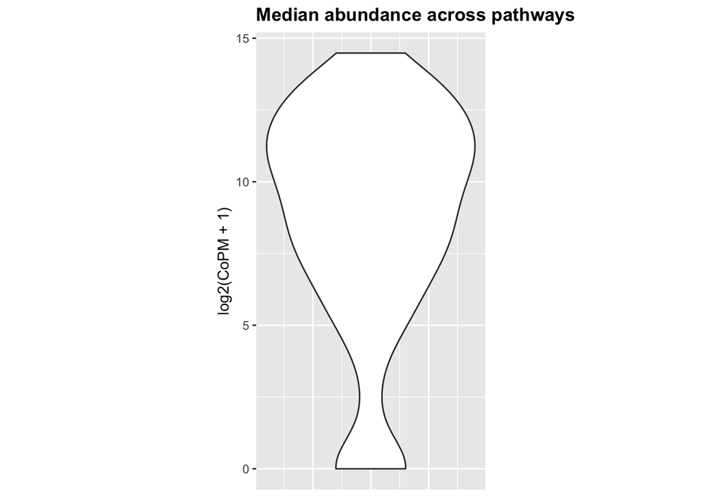

```r
p_path_violin = ggplot(data = data.frame(Abundance = median_pathabundance), aes(x = 1, y = Abundance)) +
  labs(title = "Median abundance across pathways") +
  geom_violin() +
  theme(axis.text.x = element_blank(),
        axis.ticks.x = element_blank(),
        axis.title.x = element_blank(),
        aspect.ratio = 2,
        plot.title = element_text(face="bold")) +
  ylab("log2(CoPM + 1)")
p_path_violin
```

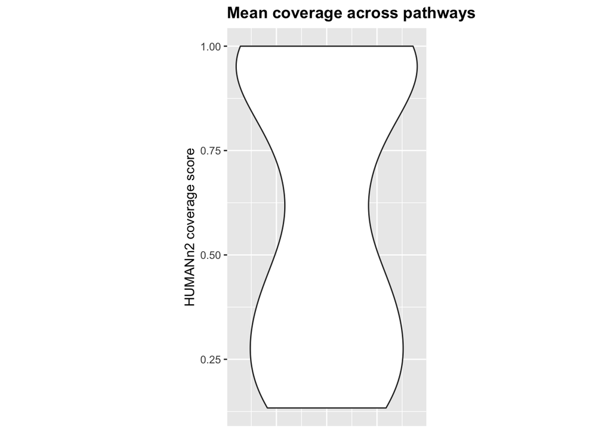

```r
p_pathCov_violin = ggplot(data = data.frame(Abundance = mean_pathCoverage), aes(x = 1, y = Abundance)) +
  labs(title = "Mean coverage across pathways") +
  geom_violin() +
  theme(axis.text.x = element_blank(),
        axis.ticks.x = element_blank(),
        axis.title.x = element_blank(),
        aspect.ratio = 2,
        plot.title = element_text(face="bold")) +
  ylab("HUMANn2 coverage score")
p_pathCov_violin
```

Median abundance across genes still looks skewed. Let’s plot a qqplot for this data.

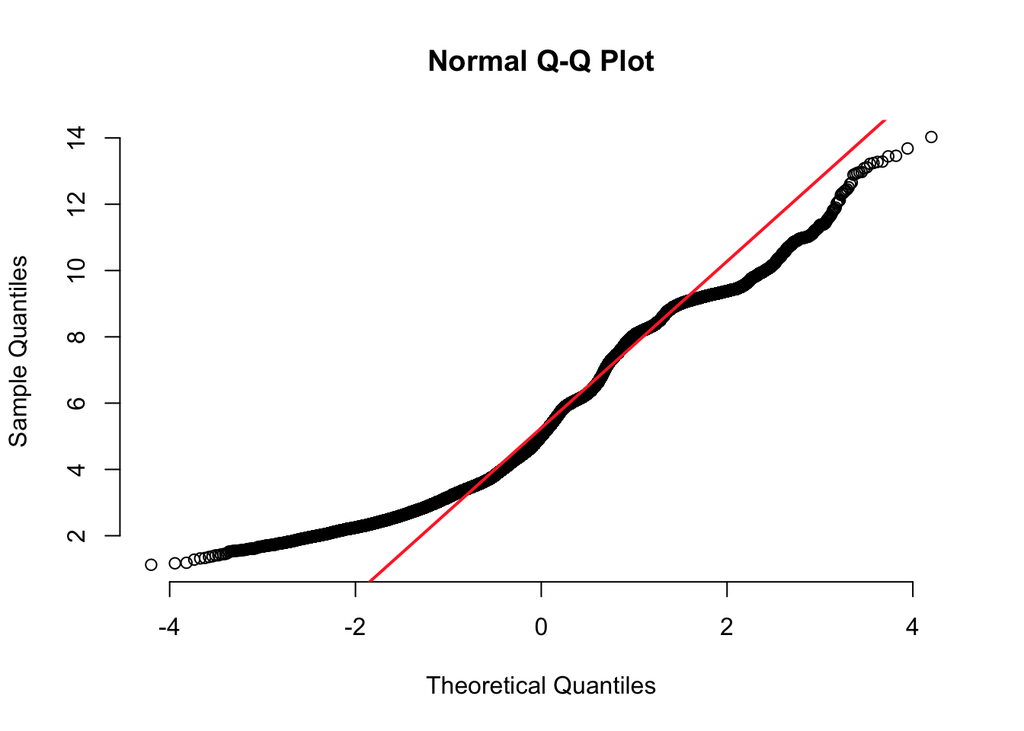

```r
qqnorm(median_geneabundance, pch = 1, frame = FALSE)
qqline(median_geneabundance, col = "firebrick1", lwd = 2)
```

### PCA

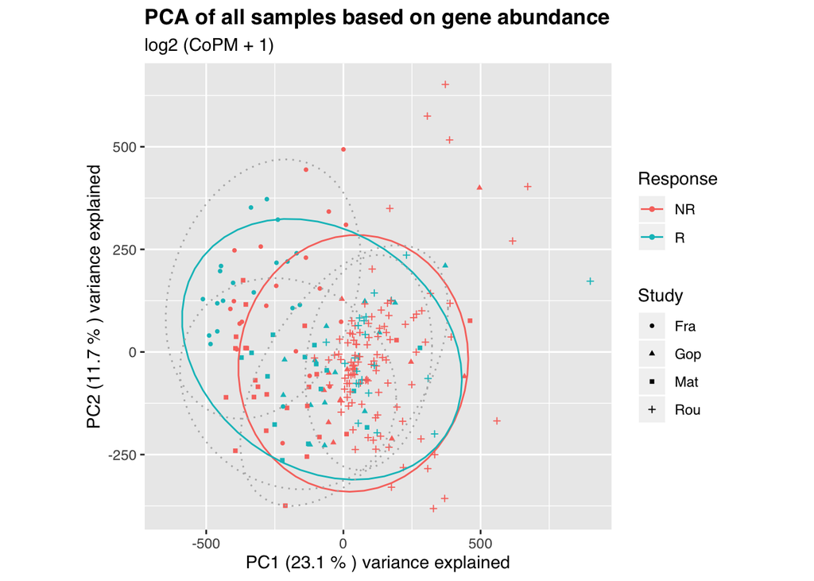

```r
# Run PCA for the gene abundance data
pca.gene = prcomp(t(geneAbundance), scale = FALSE, center = TRUE)
# Format output for ggplot
plotData = pca.gene$x[,c(1,2)]
plotData = data.frame(PC1 = as.numeric(plotData[,1]),
                      PC2 = as.numeric(plotData[,2]),
                      Response = gsub(".*_R","R",gsub(".*_NR","NR",rownames(plotData))),
                      Study = substr(rownames(plotData),6,8))
rownames(plotData) = NULL
# Call ggplot
p_gene_pca = ggplot(data = as.data.frame(plotData), aes(x = PC1, y = PC2)) +
  labs(title = "PCA of all samples based on gene abundance", subtitle = "log2 (CoPM + 1)") +
  geom_point(size = 1,aes(color = Response, shape = Study)) +
  stat_ellipse(aes(color = Response, group = Response), linetype = 1) +
  stat_ellipse(aes(group = Study), linetype = 3, color = "grey70") +
  xlab(paste("PC1 (", round(((pca.gene$sdev[1])^2)/sum((pca.gene$sdev)^2)*100,1)," % ) variance explained",sep = "")) +
  ylab(paste("PC2 (", round(((pca.gene$sdev[2])^2)/sum((pca.gene$sdev)^2)*100,1)," % ) variance explained",sep = "")) +
  theme(plot.title = element_text(face="bold")) +
  theme(text = element_text(family = "Helvetica")) +
  theme(aspect.ratio=1)

p_gene_pca
```

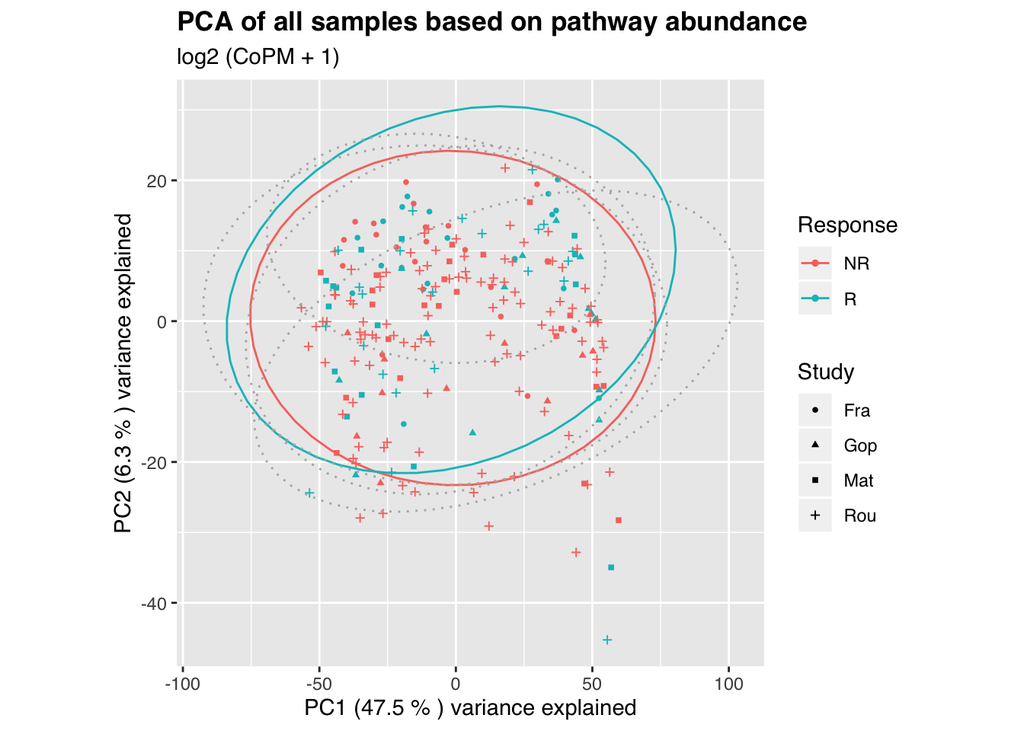

```r
# Run PCA for the pathway abundance data
pca.path = prcomp(t(pathAbundance), scale = FALSE, center = TRUE)
# Format output for ggplot
plotData = pca.path$x[,c(1,2)]
plotData = data.frame(PC1 = as.numeric(plotData[,1]),
                      PC2 = as.numeric(plotData[,2]),
                      Response = gsub(".*_R","R",gsub(".*_NR","NR",rownames(plotData))),
                      Study = substr(rownames(plotData),6,8))
rownames(plotData) = NULL
# Call ggplot
p_path_pca = ggplot(data = as.data.frame(plotData), aes(x = PC1, y = PC2)) +
  labs(title = "PCA of all samples based on pathway abundance", subtitle = "log2 (CoPM + 1)") +
  geom_point(size = 1,aes(color = Response, shape = Study)) +
  stat_ellipse(aes(color = Response, group = Response), linetype = 1) +
  stat_ellipse(aes(group = Study), linetype = 3, color = "grey70") +
  xlab(paste("PC1 (", round(((pca.path$sdev[1])^2)/sum((pca.path$sdev)^2)*100,1)," % ) variance explained",sep = "")) +
  ylab(paste("PC2 (", round(((pca.path$sdev[2])^2)/sum((pca.path$sdev)^2)*100,1)," % ) variance explained",sep = "")) +
  theme(plot.title = element_text(face="bold")) +
  theme(text = element_text(family = "Helvetica")) +
  theme(aspect.ratio=1)

p_path_pca
```

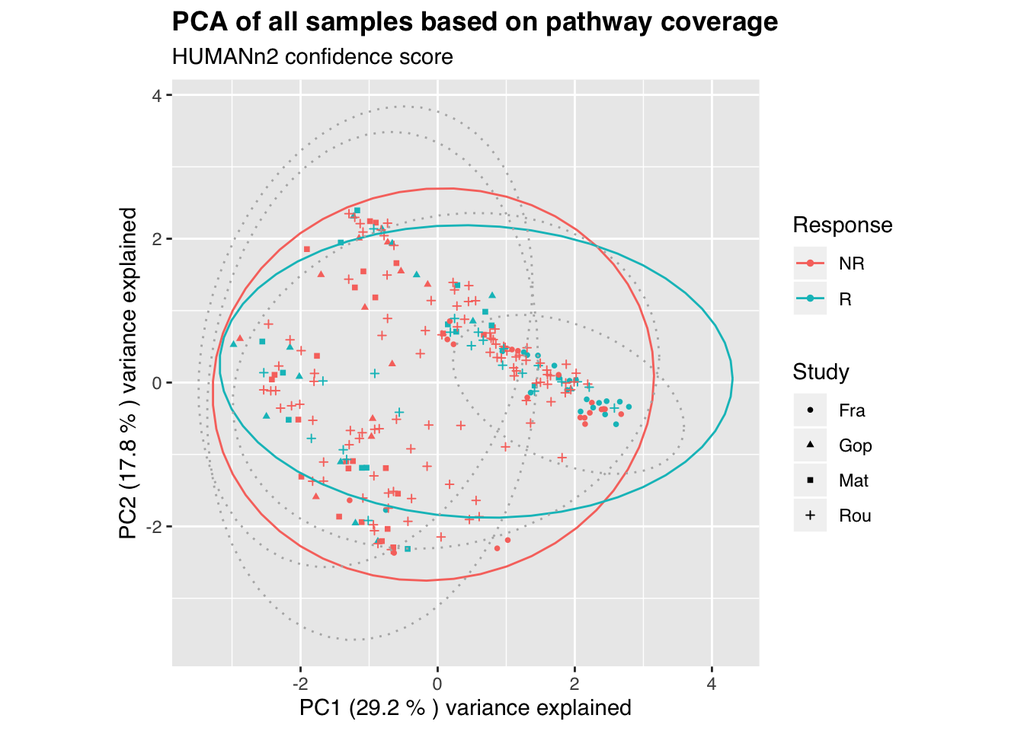

```r
# Run PCA for the pathway coverage data
pca.pathCov = prcomp(t(pathCoverage), scale = FALSE, center = TRUE)
# Format output for ggplot
plotData = pca.pathCov$x[,c(1,2)]
plotData = data.frame(PC1 = as.numeric(plotData[,1]),
                      PC2 = as.numeric(plotData[,2]),
                      Response = gsub(".*_R","R",gsub(".*_NR","NR",rownames(plotData))),
                      Study = substr(rownames(plotData),6,8))
rownames(plotData) = NULL
# Call ggplot
p_pathCov_pca = ggplot(data = as.data.frame(plotData), aes(x = PC1, y = PC2)) +
  labs(title = "PCA of all samples based on pathway coverage", subtitle = "HUMANn2 confidence score") +
  geom_point(size = 1,aes(color = Response, shape = Study)) +
  stat_ellipse(aes(color = Response, group = Response), linetype = 1) +
  stat_ellipse(aes(group = Study), linetype = 3, color = "grey70") +
  xlab(paste("PC1 (", round(((pca.pathCov$sdev[1])^2)/sum((pca.pathCov$sdev)^2)*100,1)," % ) variance explained",sep = "")) +
  ylab(paste("PC2 (", round(((pca.pathCov$sdev[2])^2)/sum((pca.pathCov$sdev)^2)*100,1)," % ) variance explained",sep = "")) +
  theme(plot.title = element_text(face="bold")) +
  theme(text = element_text(family = "Helvetica")) +
  theme(aspect.ratio=1)

p_pathCov_pca
```

### UMAP

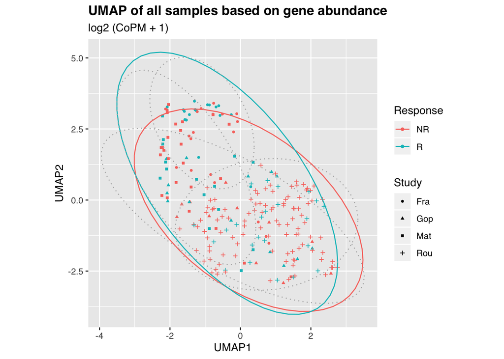

```r
# Set seed for reproducibility
set.seed(9)
# Run UMAP for the gene abundance data
umap_gene = umap(t(geneAbundance), config = umap.defaults, method = "naive")
# Format output for ggplot
plotData = umap_gene$layout[,c(1,2)]
plotData = data.frame(UMAP1 = as.numeric(plotData[,1]),
                      UMAP2 = as.numeric(plotData[,2]),
                      Response = gsub(".*_R","R",gsub(".*_NR","NR",rownames(plotData))),
                      Study = substr(rownames(plotData),6,8))
rownames(plotData) = NULL
# Call ggplot
p_gene_UMAP = ggplot(data = as.data.frame(plotData), aes(x = UMAP1, y = UMAP2)) +
  labs(title = "UMAP of all samples based on gene abundance", subtitle = "log2 (CoPM + 1)") +
  geom_point(size = 1,aes(color = Response, shape = Study)) +
  stat_ellipse(aes(color = Response, group = Response), linetype = 1) +
  stat_ellipse(aes(group = Study), linetype = 3, color = "grey70") +
  xlab("UMAP1") +
  ylab("UMAP2") +
  theme(plot.title = element_text(face="bold")) +
  theme(text = element_text(family = "Helvetica")) +
  theme(aspect.ratio=1)
p_gene_UMAP
```

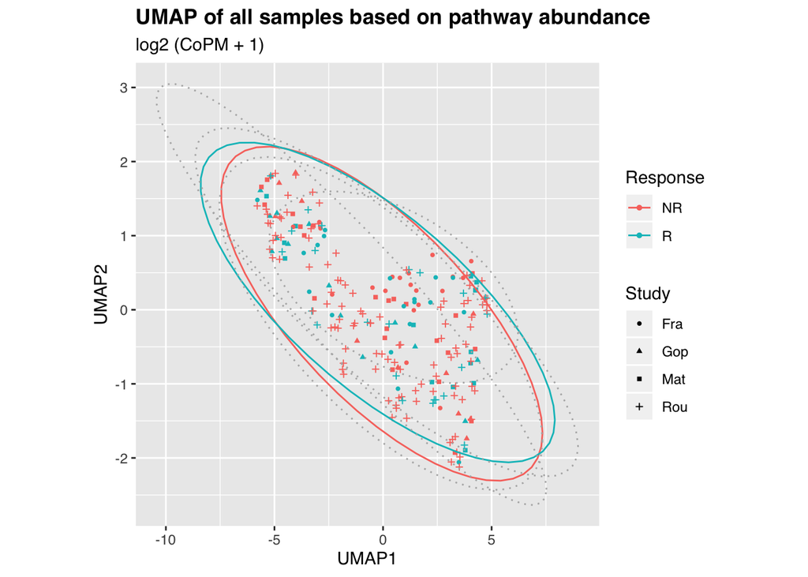

```r
# Set seed for reproducibility
set.seed(9)
umap_path = umap(t(pathAbundance), config = umap.defaults, method = "naive")
# Format output for ggplot
plotData = umap_path$layout[,c(1,2)]
plotData = data.frame(UMAP1 = as.numeric(plotData[,1]),
                      UMAP2 = as.numeric(plotData[,2]),
                      Response = gsub(".*_R","R",gsub(".*_NR","NR",rownames(plotData))),
                      Study = substr(rownames(plotData),6,8))
rownames(plotData) = NULL
# Call ggplot
p_path_UMAP = ggplot(data = as.data.frame(plotData), aes(x = UMAP1, y = UMAP2)) +
  labs(title = "UMAP of all samples based on pathway abundance", subtitle = "log2 (CoPM + 1)") +
  geom_point(size = 1,aes(color = Response, shape = Study)) +
  stat_ellipse(aes(color = Response, group = Response), linetype = 1) +
  stat_ellipse(aes(group = Study), linetype = 3, color = "grey70") +
  xlab("UMAP1") +
  ylab("UMAP2") +
  theme(plot.title = element_text(face="bold")) +
  theme(text = element_text(family = "Helvetica")) +
  theme(aspect.ratio=1)
p_path_UMAP
```

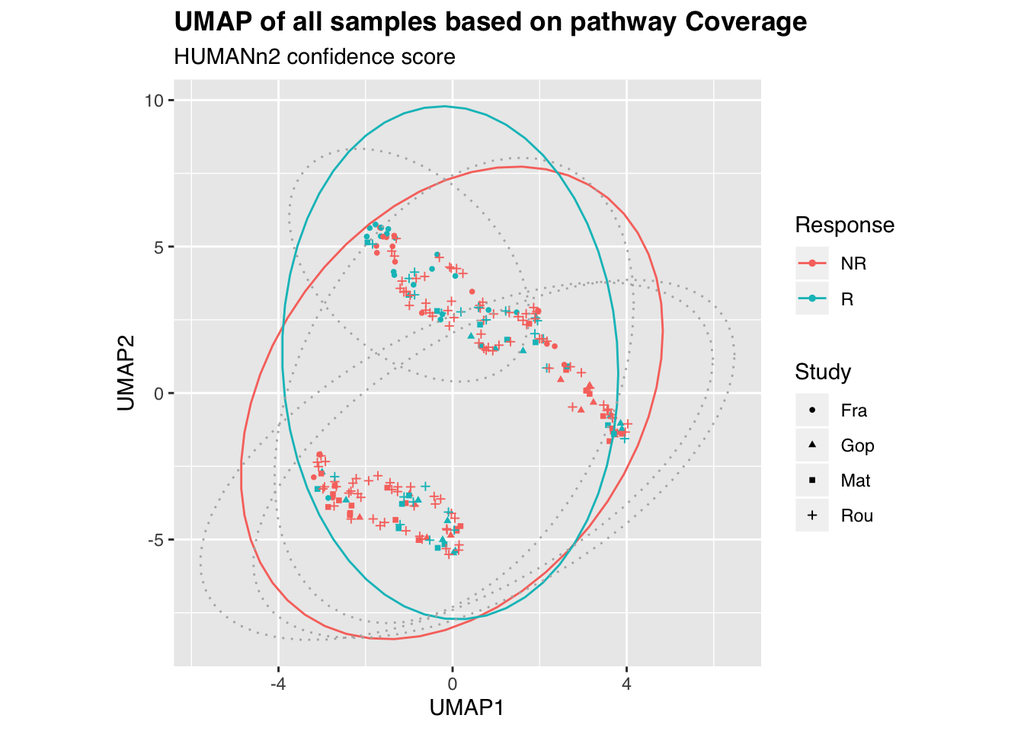

```r
# Set seed for reproducibility
set.seed(9)
umap_pathCov = umap(t(pathCoverage), config = umap.defaults, method = "naive")
# Format output for ggplot
plotData = umap_pathCov$layout[,c(1,2)]
plotData = data.frame(UMAP1 = as.numeric(plotData[,1]),
                      UMAP2 = as.numeric(plotData[,2]),
                      Response = gsub(".*_R","R",gsub(".*_NR","NR",rownames(plotData))),
                      Study = substr(rownames(plotData),6,8))
rownames(plotData) = NULL
# Call ggplot
p_pathCov_UMAP = ggplot(data = as.data.frame(plotData), aes(x = UMAP1, y = UMAP2)) +
  labs(title = "UMAP of all samples based on pathway Coverage", subtitle = "HUMANn2 confidence score") +
  geom_point(size = 1,aes(color = Response, shape = Study)) +
  stat_ellipse(aes(color = Response, group = Response), linetype = 1) +
  stat_ellipse(aes(group = Study), linetype = 3, color = "grey70") +
  xlab("UMAP1") +
  ylab("UMAP2") +
  theme(plot.title = element_text(face="bold")) +
  theme(text = element_text(family = "Helvetica")) +
  theme(aspect.ratio=1)
p_pathCov_UMAP
```

### Differential Abundance

```r
# Initialise empty data frame for storing differentially abundant genes
DEgenes = data.frame(pvalue = 1:nrow(geneAbundance), fold_change = 1:nrow(geneAbundance))
rownames(DEgenes) = rownames(geneAbundance)

# Loop over all genes
for (i in 1:nrow(geneAbundance)) {
  # Extract abundances of each gene for both R and NR
  R_abundance = as.numeric(geneAbundance[i,grepl("_R",colnames(geneAbundance))])
  NR_abundance = as.numeric(geneAbundance[i,grepl("_NR",colnames(geneAbundance))])

  DEgenes$pvalue[i] = wilcox.test(R_abundance,NR_abundance, alternative = "two.sided")$p.value
  DEgenes$fold_change[i] = log2((median(R_abundance) + 1)/(median(NR_abundance) + 1))
}

## Adjust for multiple testing
#DEgenes$pvalue = p.adjust(DEgenes$pvalue,method = "fdr")
# Order according to most significant genes
DEgenes = DEgenes[order(DEgenes$pvalue),]
# Keep only significant genes (P < 0.05)
DEgenes = DEgenes[DEgenes$pvalue < 0.05,]

print(DEgenes)
```

```
##                             pvalue fold_change
## UniRef90_R6CTL5        0.009840316 -0.11488458
## UniRef90_I8ZI00        0.011232066 -0.15083920
## UniRef90_R0BYR7        0.013080181 -0.14884173
## UniRef90_I9QAJ8        0.016302286 -0.10739309
## UniRef90_G5SMZ1        0.022022695 -0.16687597
## UniRef90_Q5LCI1        0.023659278 -0.10784091
## UniRef90_A0A016F992    0.025708371 -0.20139873
## UniRef90_A8S862        0.026590699  0.14351402
## UniRef90_Q8A6W4        0.027421373 -0.07868622
## UniRef90_UPI00046E7971 0.027505932 -0.11063536
## UniRef90_A0A015SC43    0.028628489 -0.14065301
## UniRef90_Q8A6W5        0.028659248 -0.10572915
## UniRef90_R6CGW6        0.031699853 -0.12859026
## UniRef90_A0A016BMV0    0.033051211 -0.17968469
## UniRef90_Q8A538        0.033519357 -0.09827182
## UniRef90_E2ZJ20        0.035676319  0.11686611
## UniRef90_Q5LG30        0.035749111 -0.10325502
## UniRef90_Q5LHC9        0.039844613 -0.13865657
## UniRef90_R5M3G4        0.041464444 -0.12515165
## UniRef90_N9YFW0        0.044131825 -0.16522505
## UniRef90_A7V3J2        0.044410136 -0.04010791
## UniRef90_U2AZI4        0.046539285 -0.10893754
## UniRef90_Q8A6W6        0.047807483 -0.05547944
## UniRef90_R7KWF0        0.049873366 -0.12562968
```

```r
# Initialise empty data frame for storing differentially abundant genes
DEpaths = data.frame(pvalue = 1:nrow(pathAbundance), fold_change = 1:nrow(pathAbundance))
rownames(DEpaths) = rownames(pathAbundance)

# Loop over all paths
for (i in 1:nrow(pathAbundance)) {
  # Extract abundances of each path for both R and NR
  R_abundance = as.numeric(pathAbundance[i,grepl("_R",colnames(pathAbundance))])
  NR_abundance = as.numeric(pathAbundance[i,grepl("_NR",colnames(pathAbundance))])

  DEpaths$pvalue[i] = wilcox.test(R_abundance,NR_abundance, alternative = "two.sided")$p.value
  DEpaths$fold_change[i] = log2((median(R_abundance) + 1)/(median(NR_abundance) + 1))
}

## Adjust for multiple testing
#DEpaths$pvalue = p.adjust(DEpaths$pvalue,method = "fdr")
# Order according to most significant paths
DEpaths = DEpaths[order(DEpaths$pvalue),]
# Keep only significant paths (P < 0.05)
DEpaths = DEpaths[DEpaths$pvalue < 0.05,]

print(DEpaths)
```

```
##                                                                                  pvalue
## PWY-6507: 4-deoxy-L-threo-hex-4-enopyranuronate degradation                  0.02304644
## PWY-7242: D-fructuronate degradation                                         0.04237147
## PWY-5177: glutaryl-CoA degradation                                           0.04620149
## GALACT-GLUCUROCAT-PWY: superpathway of hexuronide and hexuronate degradation 0.04803109
## GALACTUROCAT-PWY: D-galacturonate degradation I                              0.04815946
##                                                                              fold_change
## PWY-6507: 4-deoxy-L-threo-hex-4-enopyranuronate degradation                   0.04066208
## PWY-7242: D-fructuronate degradation                                          0.02515082
## PWY-5177: glutaryl-CoA degradation                                            0.03523014
## GALACT-GLUCUROCAT-PWY: superpathway of hexuronide and hexuronate degradation  0.01250807
## GALACTUROCAT-PWY: D-galacturonate degradation I                               0.02035835
```

In order to better visualise the difference, lets plot a heatmap of the differentially abundant genes/pathways.

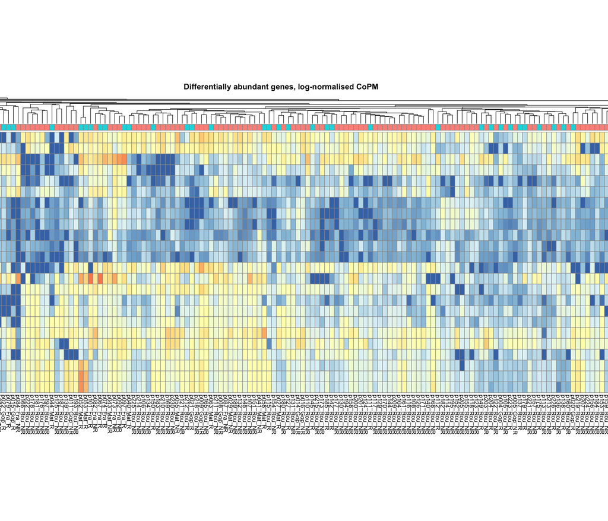

```r
# Define metrics for clustering
drows1 <- "euclidean"
dcols1 <- "euclidean"
# Create annotations for gene heatmap
hm.cols = data.frame(Response = gsub(".*_R","R",gsub(".*_NR","NR",colnames(geneAbundance))))
hm.cols$Response = factor(hm.cols$Response,levels(hm.cols$Response)[c(2,1)])
rownames(hm.cols) = colnames(geneAbundance)
# Create heatmap
# type "?pheatmap()" for more help
# CairoWin()
pheatmap(geneAbundance[rownames(DEgenes),],
         kmeans_k = NA,
         show_rownames = TRUE, show_colnames = TRUE,
         main = "Differentially abundant genes, log-normalised CoPM",
         clustering_method = "average",
         cluster_rows = TRUE, cluster_cols = TRUE,
         clustering_distance_rows = drows1,
         clustering_distance_cols = dcols1,
         annotation_col = hm.cols,
         fontsize_row = 10,
         cellwidth = 8,
         cellheight = 18,
         legend = F,
         annotation_legend = F
)
```

The classes don’t seem to separate that much. Let’s try PCA.

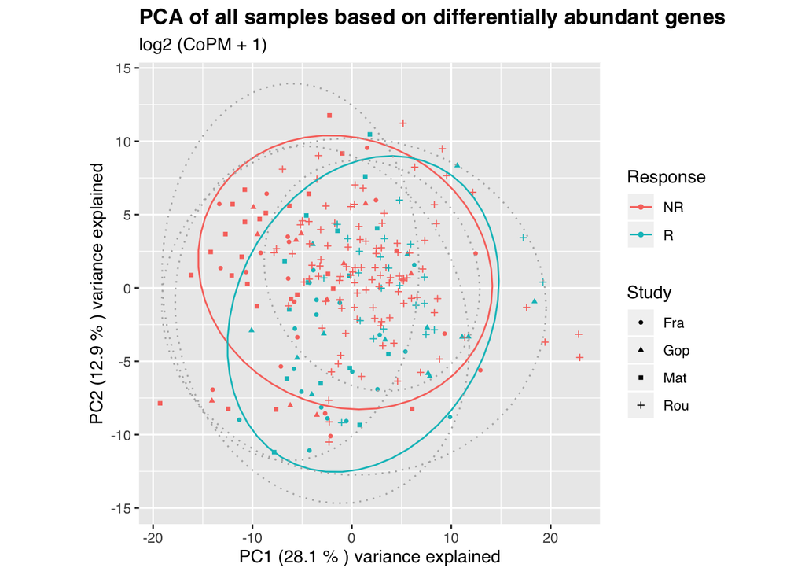

```r
# Run PCA for the gene abundance data
pca.gene = prcomp(t(geneAbundance[rownames(DEgenes),]), scale = FALSE, center = TRUE)
# Format output for ggplot
plotData = pca.gene$x[,c(1,2)]
plotData = data.frame(PC1 = as.numeric(plotData[,1]),
                      PC2 = as.numeric(plotData[,2]),
                      Response = gsub(".*_R","R",gsub(".*_NR","NR",rownames(plotData))),
                      Study = substr(rownames(plotData),6,8))
rownames(plotData) = NULL
# Call ggplot
p_gene_pca = ggplot(data = as.data.frame(plotData), aes(x = PC1, y = PC2)) +
  labs(title = "PCA of all samples based on differentially abundant genes", subtitle = "log2 (CoPM + 1)") +
  geom_point(size = 1,aes(color = Response, shape = Study)) +
  stat_ellipse(aes(color = Response, group = Response), linetype = 1) +
  stat_ellipse(aes(group = Study), linetype = 3, color = "grey70") +
  xlab(paste("PC1 (", round(((pca.gene$sdev[1])^2)/sum((pca.gene$sdev)^2)*100,1)," % ) variance explained",sep = "")) +
  ylab(paste("PC2 (", round(((pca.gene$sdev[2])^2)/sum((pca.gene$sdev)^2)*100,1)," % ) variance explained",sep = "")) +
  theme(plot.title = element_text(face="bold")) +
  theme(text = element_text(family = "Helvetica")) +
  theme(aspect.ratio=1)

p_gene_pca
```

### Random Forests

Let’s add our clinical data as a feature in our Abundance matrices.

```r
gene_train = cbind(t(geneAbundance),
                   Treatment = clin$Treatment,
                   Study = clin$Study,
                   Cancer_type = clin$Cancer_type)
path_train = cbind(t(pathAbundance),
                   Treatment = clin$Treatment,
                   Study = clin$Study,
                   Cancer_type = clin$Cancer_type)
```

Data is now ready for random forest classification. Let’s check the top predictors

```r
# Set seed for reproducibility
set.seed(9)
# Set number of trees in RF
n_tree = 1000
# Construct random forest model for genes
rf.gene <- randomForest(x=gene_train,y=clin$Response, ntree = n_tree ,importance = TRUE)
# View confusion matrix
print(rf.gene$confusion)
```

```
##     NR  R class.error
## NR 147 12   0.0754717
## R   54 17   0.7605634
```

```r
# View the most important (Mean decrease of GINI impurity) features for prediction
rf.gene.importance <- data.frame(importance(rf.gene, type = 2)) %>%
  rownames_to_column('Gene') %>%
  arrange(desc(MeanDecreaseGini))
print(rf.gene.importance[1:20,])
```

```
##               Gene MeanDecreaseGini
## 1  UniRef90_R6ZQZ4       0.08797297
## 2  UniRef90_R7CFX8       0.08390477
## 3  UniRef90_R7CMS9       0.08015304
## 4  UniRef90_R5RM09       0.07811713
## 5  UniRef90_K1U071       0.06662282
## 6  UniRef90_I8ZI00       0.06529902
## 7  UniRef90_D4JR78       0.06518889
## 8  UniRef90_D4KMQ4       0.06430995
## 9  UniRef90_K1TAV8       0.06422141
## 10 UniRef90_E5UZF8       0.06307902
## 11 UniRef90_A7VXB6       0.06135604
## 12 UniRef90_F4XC42       0.06099744
## 13 UniRef90_R7CPN7       0.05932373
## 14 UniRef90_R7CIW0       0.05872155
## 15 UniRef90_A6L0F5       0.05867886
## 16 UniRef90_K1TP71       0.05740087
## 17 UniRef90_K1T8H5       0.05723751
## 18 UniRef90_R6EI91       0.05470684
## 19 UniRef90_R5R2E3       0.05320991
## 20 UniRef90_R9LJ43       0.05290487
```

We can evaluate the model with a ROC-curve.

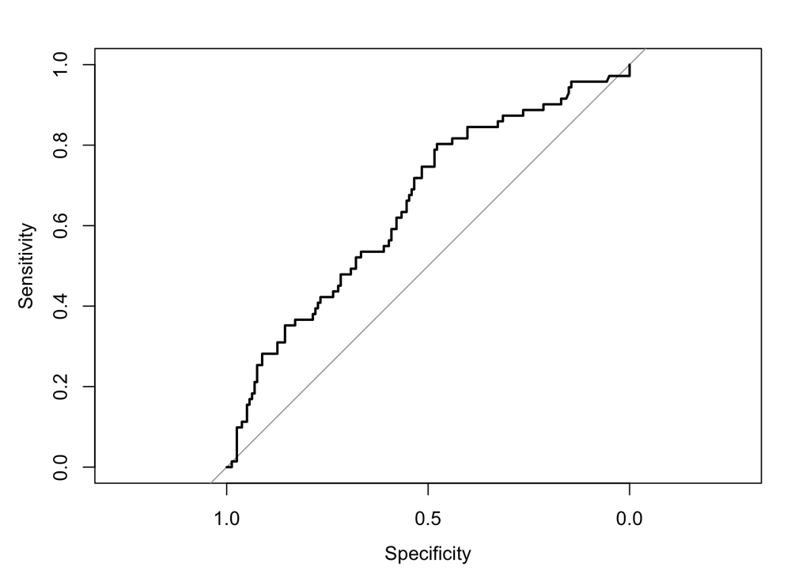

```r
# Generate ROC-curve for training data
rf.gene.roc = roc(as.factor(clin$Response),rf.gene$votes[,2])
plot(rf.gene.roc)
```

```r
auc(rf.gene.roc)
```

```
## Area under the curve: 0.6511
```

We seem to get an AUC of 0.6511 with a 1000-tree RF.

Let’s produce violin plots comparing abundances of the top R/NR predicting genes

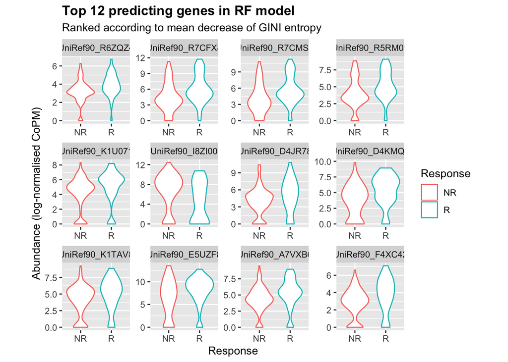

```r
# Let's plot the top predictiors
nPlot = 12
# Select top predictors from OTU matrix and format for ggplot
plotData = as.matrix(gene_train[,rf.gene.importance$Gene[1:nPlot]])
plotData = melt(plotData)
plotData = cbind(plotData, Response = gsub(".*_R","R",gsub(".*_NR","NR",plotData$Var1)))
colnames(plotData) = c("Patient","Gene","Abundance","Response")
p_RFpredictors = ggplot(data = plotData,aes(x=Response,y=Abundance,color=Response)) +
  facet_wrap(facets = "Gene",ncol = 4, scales = "free") +
  geom_violin() +
  ylab("Abundance (log-normalised CoPM)") +
  labs(title = "Top 12 predicting genes in RF model", subtitle = "Ranked according to mean decrease of GINI entropy") +
  theme(plot.title = element_text(face="bold")) +
  theme(aspect.ratio=1)
p_RFpredictors
```

**Function of most important UniRef90 sequences enriched in R** * R6ZQZ4 + O-acetylhomoserine aminocarboxypropyltransferase/cysteine synthase + Amino acid metabolism * R7CFX8 + NTP_transferase domain-containing protein * R7CMS9 + Cobalamin biosynthesis protein CobD + Cofactor Biosynthesis + Ruminococcus sp. CAG:9 * R5RM09 + 2-polyprenylphenol hydroxylase and related flavodoxin oxidoreductases * K1U071 + 3-oxoacyl-(acyl-carrier-protein) reductase + Fatty acid biosynthesis and polyunsaturated fatty acid biosynthesis

### TO-DO

- limma?
- Figure out optimal normalisation strategy
  - Vary filtering criteria
  - Use some other metric than CoPM
  - Cluster genes
- XGBoost on Genes
- Split NR and R into four classes
  - Based on RECIST scores
- Plot Covariate normalized abundances?
- Run study-by-study analysis…
- Include phylogenetic distance between genes in RF